# Examples of collaborative workflows

### Option 2: RStudio

Open up your project in RStudio and click on the “New branch” button in the **Git** pane (i.e., the button with the 2 purple rectangles and a diamond).

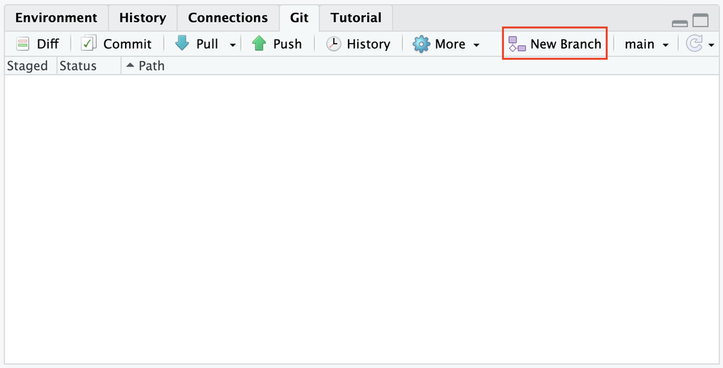

Click on the button labeled “Add remote…”.

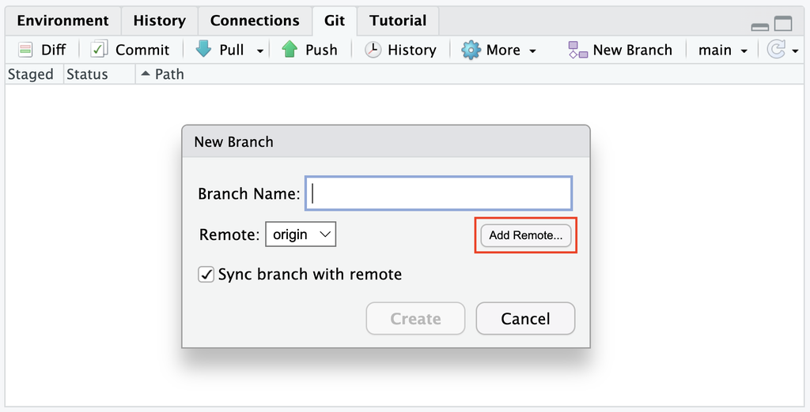

- In the “Remote Name:” box, type `upstream`.
- In the “Remote URL:” box, enter the name of the **owner’s** repo you forked in Step 1: `https://github.com/FISH549/ex-fork` (you can copy/paste if you’d like).
- When you are finished, click the **Add** button.

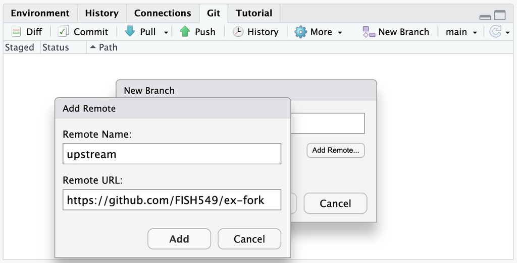

Click on the **Cancel** button (don’t worry, everything is still OK).

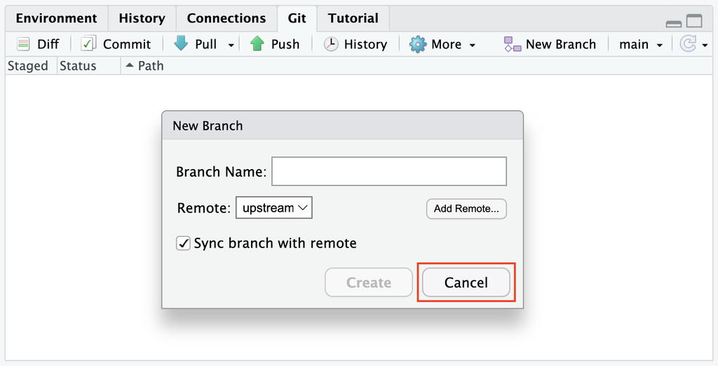

Now you need to verify that the remote `upstream` is set up properly. To do so, click on the **Terminal** tab in your Console pane and type this:

```bash
$ git remote -v
```

which should return the following, where `USERNAME` is your user name.

```bash
origin  https://github.com/USERNAME/ex-fork (fetch)
origin  https://github.com/USERNAME/ex-fork (push)
upstream        https://github.com/FISH549/ex-fork (fetch)
upstream        https://github.com/FISH549/ex-fork (push)
```

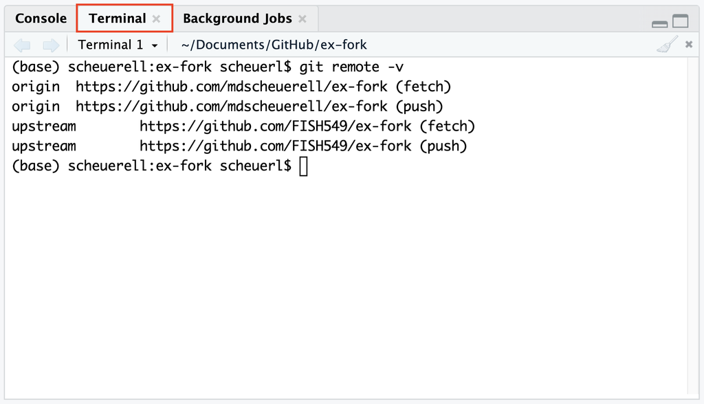

## Step 4: Make local changes

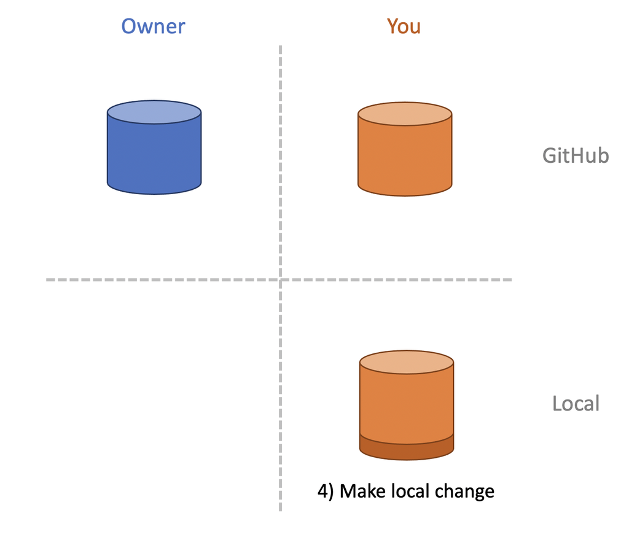

Now you are ready to make any changes you’d like to the files or folders in your local repo.

**Before doing so**, make sure to **pull** any changes that might have been made to the owner’s `upstream` remote.

To do so, again navigate to the **Terminal** tab in RStudio and type:

```bash
$ git pull upstream main --ff-only
```

If nothing has changed, you’ll see a message like this:

```
From https://github.com/FISH549/ex-fork
 * branch            main       -> FETCH_HEAD
 * [new branch]      main       -> upstream/main
Already up to date.
```

### Setting the local branch

If you examine your forked copy of the repo on GitHub, you’ll notice that it contains 2 branches: **main** and **develop**. However, if you inspect the local branches in your current project in RStudio, you’ll see that only **main** exists there.

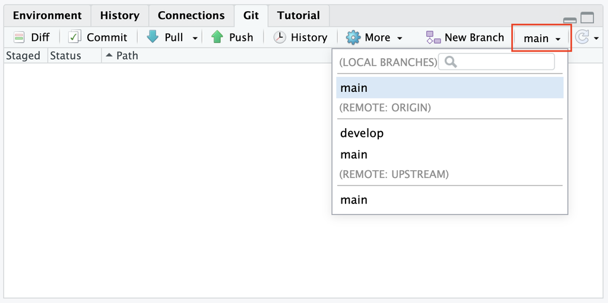

To set the local branch to **develop** (where we’d like to do our work), click on **develop** under (REMOTE: ORIGIN), which will bring up a message box from Git informing you that you’ve created and switched over to a new branch called **develop**.

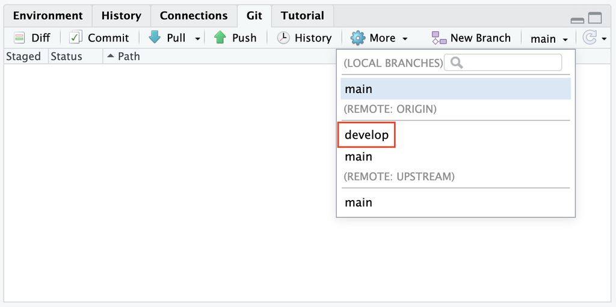

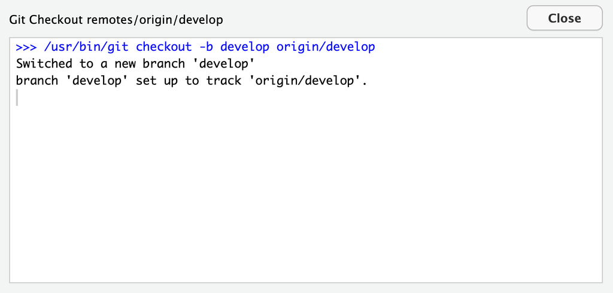

Close the window and you will see that the branch name in the **Git** pane of RStudio is set to **develop**.

If you again click on the **develop** button it will now show that you can track the **develop** and **main** branches on

- your local repo
- your remote origin (located at `https://github.com/USERNAME/ex-fork`)

You can also track the **main branch** on the remote upstream (located at `https://github.com/FISH549/ex-fork`)

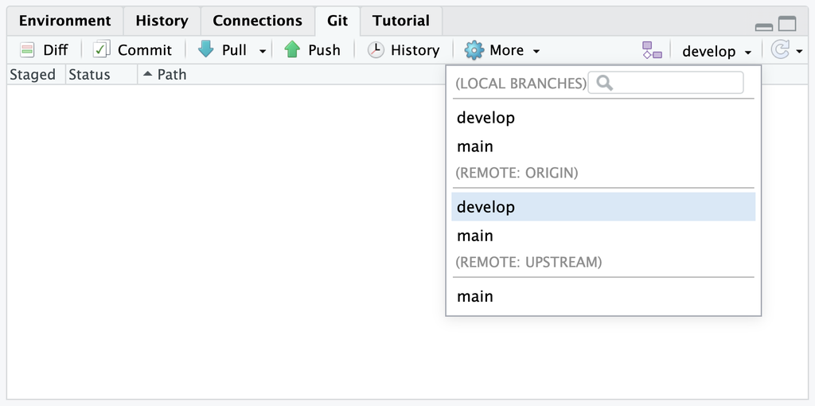

Let’s create a new file in our local repo so we have something to commit and push to our own remote repo, and then ultimately submit it as a pull request to the original repo’s owner (here `FISH549`).

Go ahead and make a simple R script and commit it (I’m called mine `simple_addition.R`).

[figure not shown]

When you’re happy with your script, go ahead and commit it.

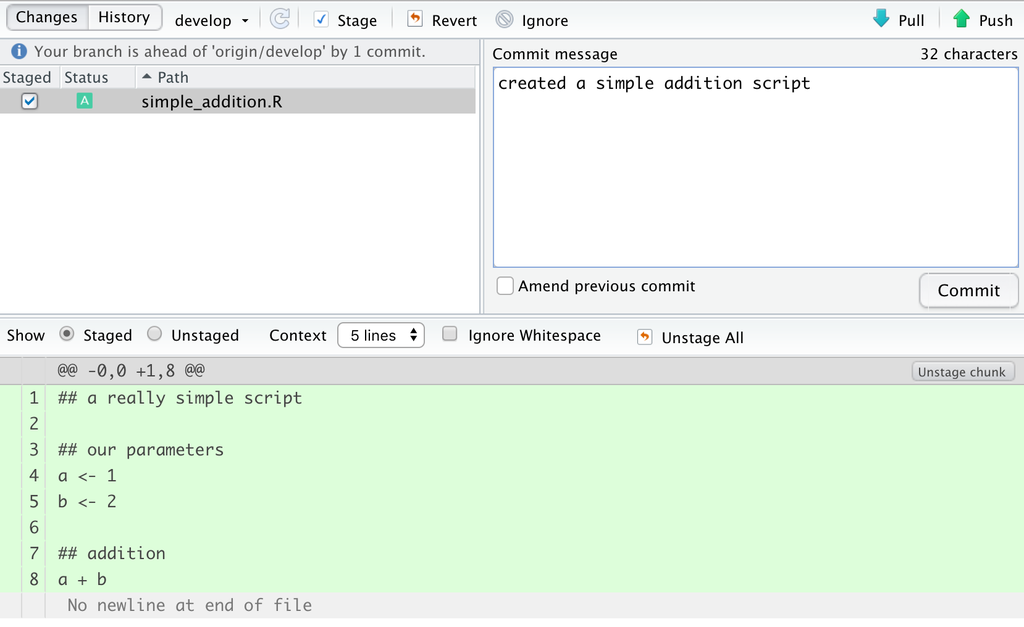

## Step 5: Push to GitHub

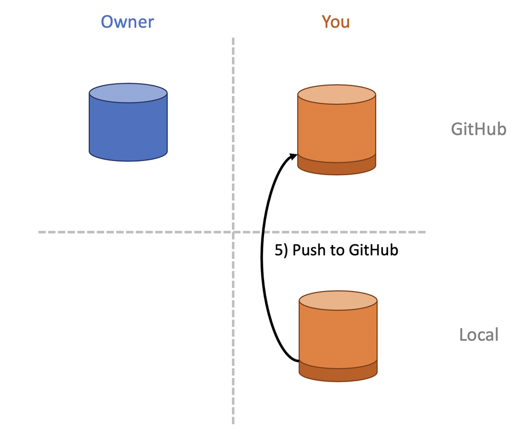

Now it’s time to push your simple script to your own remote located at

`https://github.com/USERNAME/ex-fork`

Click the green uparrow to push your new script to GitHub.

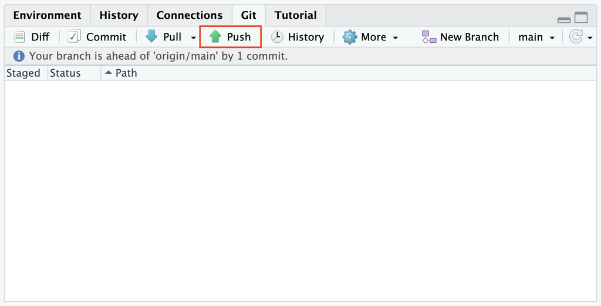

## Step 6: Submit a pull request

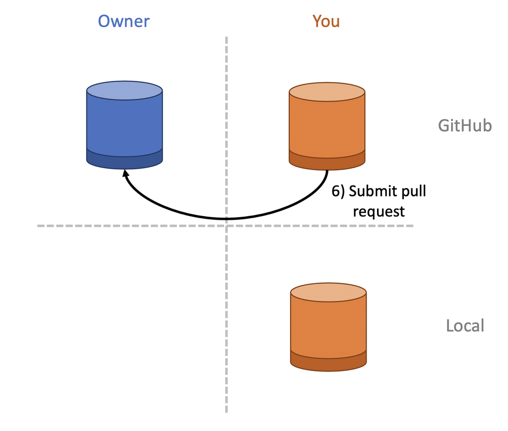

Navigate to your forked repo on GitHub where you’ll see a message about this branch having a recent push and a new green button labeled **Compare & pull request**.

[figure not shown]

Open a pull request by clicking on the green **Compare & pull request** button.

This will take you to the standard page for a pull request, just as we saw in the feature branch workflow above. In this case, however, there is additional information about 2 things:

- the location of the upstream repo (here it’s `https://github.com/FISH549/ex-fork`)
- the *locations* and *branches* (here **develop**) of the base and head repositories

[figure not shown]

It’s good practice to give your pull request an informative title and include some additional information about the substance of the pull request, so that the owner of the original repo has some understanding of what you’ve done.

Give your pull request a title and description. When ready, click on the green **Create pull request** button, which will take you to a page showing the details of your pull request.

[figure not shown]

[figure not shown]

No you just have to wait for the repo’s owner to review the pull request and either accept it as is, or come back to you with additional comments or requests for changes.